# Distribution of seats by departement for Assemblée Nationale and Senat

Prelimlinary statistical explorations

Author

Claude Grasland

Published

November 9, 2026

## Objective

This short note aims to examine the distribution of seats in the Sénat and the Assemblée Nationale by département in the Metropolitan area of France (excluding Corsica). We propose to test the following hypothesis :

- **H1:** The correlation between the number of seats and population is more important with past census than the present, due to the lack of recent updates.
- **H2:** The relation between the number of seats and the number of registered population in 2024 is characterised by negative residuals in départements with important population growth in recent years and positive residuals in départements with declining or stable population.
- **H3:** The relation between population and number of seats is much lower in the case of the Sénat.

## Data

We limit our analysis to the département of métroolitan France (excluding Corse). The variables to be explained are :

- NBDEP : number of seats at Assemblée Nationale in 2024
- NBSEN : number of seats at Sénat in 2024
- I2024 : number of registered citizens in voting office at european election of 2024
- P1968..P2023 : Total number of inhabitants according to census

|  | dept | dept_nom | regi | regi_nom | I2024 | NBDEP | NBSEN | P1968 | P1975 | P1982 | P1990 | P1999 | P2010 | P2015 | P2021 | P2023 | SUP | DEN |
| --- | --- | --- | --- | --- | --- | --- | --- | --- | --- | --- | --- | --- | --- | --- | --- | --- | --- | --- |
| 1 | 01 | Ain | 84 | Auvergne-Rhône-Alpes | 449217 | 5 | 3 | 339262 | 376477 | 418516 | 471019 | 515270 | 597341 | 631877 | 663202 | 679344 | 5762.4 | 117.9 |
| 2 | 02 | Aisne | 32 | Hauts-de-France | 373728 | 5 | 3 | 525953 | 533807 | 533927 | 537200 | 535434 | 540508 | 538659 | 527468 | 523342 | 7361.7 | 71.7 |
| 3 | 03 | Allier | 84 | Auvergne-Rhône-Alpes | 249428 | 3 | 2 | 386533 | 378406 | 369580 | 357710 | 344721 | 342908 | 341613 | 334872 | 333298 | 7340.1 | 45.6 |
| 4 | 04 | Alpes-de-Haute-Provence | 93 | Provence-Alpes-Côte d'Azur | 129172 | 2 | 1 | 104813 | 112178 | 119068 | 130883 | 139561 | 160149 | 161799 | 166077 | 168054 | 6925.2 | 24 |
| 5 | 05 | Hautes-Alpes | 93 | Provence-Alpes-Côte d'Azur | 115059 | 2 | 1 | 91790 | 97358 | 105070 | 113300 | 121419 | 136971 | 140916 | 140976 | 143467 | 5548.7 | 25.4 |
| 6 | 06 | Alpes-Maritimes | 93 | Provence-Alpes-Côte d'Azur | 789750 | 9 | 5 | 722070 | 816681 | 881198 | 971829 | 1011326 | 1078729 | 1082440 | 1103941 | 1128418 | 4298.6 | 262.6 |
| 7 | 07 | Ardèche | 84 | Auvergne-Rhône-Alpes | 259237 | 3 | 2 | 256927 | 257065 | 267970 | 277581 | 286023 | 315090 | 324209 | 331415 | 334231 | 5528.6 | 59.9 |
| 8 | 08 | Ardennes | 44 | Grand Est | 186869 | 3 | 2 | 309380 | 309306 | 302338 | 296357 | 290130 | 283250 | 277752 | 268859 | 265893 | 5229.4 | 51.4 |
| 9 | 09 | Ariège | 76 | Occitanie | 120494 | 2 | 1 | 138478 | 137857 | 135725 | 136455 | 137205 | 152038 | 152499 | 154596 | 155722 | 4889.9 | 31.6 |
| 10 | 10 | Aube | 44 | Grand Est | 203935 | 3 | 2 | 270325 | 284823 | 289300 | 289207 | 292131 | 303327 | 309056 | 311329 | 310447 | 6004.2 | 51.9 |

[output cut: 84 more lines]

## (A) Seats and historical population

We examine the correlation between the number of seats by department in 2024 and the total population in the past and present. The objective is to determine which (implicit) census year was used to allocate the number of seats.

### Linear correlation

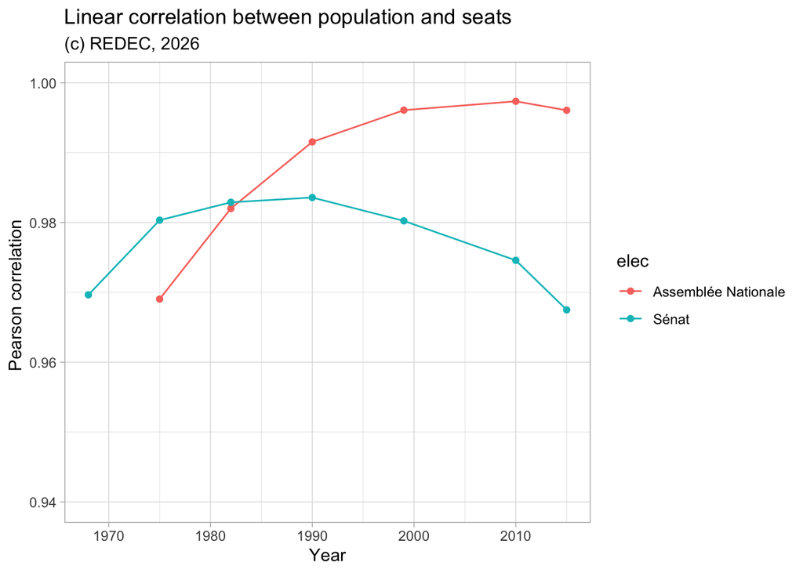

- **Comment:** The maximum correlation for the Assemblée Nationale occurs in 2010, which seems logical, as it marks the last modification of territorial divisions. The case of the Sénat is trickier, as the maximum correlation is observed in 1990…

### Rank correlation

Do we observe a different conclusion if we use the rank correlation ?

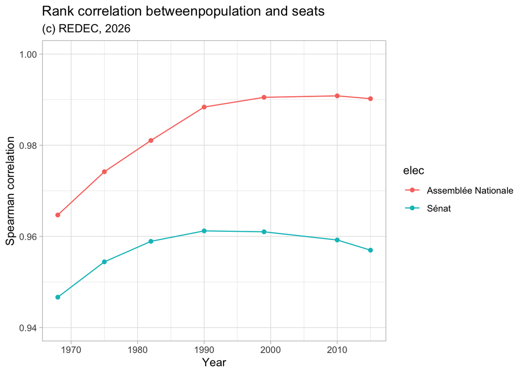

- **Comment:** The conclusion remains the same when we use the more robust rank-correlation indicator, with a maximum in 2010 for the Assemblée Nationale and 1990 for the Sénat. The gap between the two institutions is higher than in the previous case.

## (B) Seats and registered citizens in 2024

We propose a model of allocation of seats $N_i$ according to number of register $R_i$ but following a power law with a parameter $\alpha$ indicating if the allocation has been made in strict proportion $\alpha=1$, or with advantage to smaller départements ($\alpha < 1$) or larger départements ($\alpha > 1$) :

$N_i = k.R_i^\alpha$

### Assemblée Nationale

```
    Pearson's product-moment correlation

data:  log(don$I2024) and log(don$NBDEP)
t = 46.642, df = 92, p-value < 2.2e-16
alternative hypothesis: true correlation is not equal to 0
95 percent confidence interval:
 0.9692468 0.9863627
sample estimates:
      cor
0.9795032
```

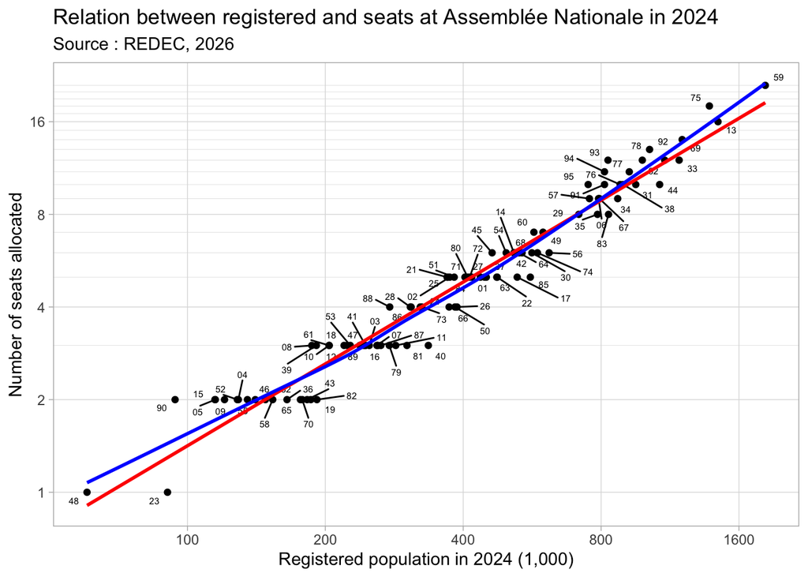

- **Comment** : The assumption of the existence of a power relation between the number of seats and registered citizens in 2024 is reasonable ($r=0.980$ and $p < 0.001$). The plot does not reveal particular autocorrelation problems: the power model (red) is very similar to the non-linear LOESS estimate (blue). However, we can notice some heteroscedasticity due to important variations in registered population in departments represented by 2 or 3 seats. Territoire de Belfort (90), with 94,000 registered citizens, has 2 seats, the same as Corrèze (19), which has twice as many registered citizens (186,000). Ardennes, with the same number of registered citizens as Corrèze, has 3 seats…

| **Characteristic** | **log(IRR)** | **95% CI** | **p-value** |
| --- | --- | --- | --- |
| (Intercept) | -10 | -12, -8.7 | <0.001 |
| log(I2024) | 0.93 | 0.80, 1.1 | <0.001 |

Abbreviations: CI = Confidence Interval, IRR = Incidence Rate Ratio

- **Comment :** According to the results of the model the allocation seems to offer an advantage to smalle départements ($\alpha = 0.93$) but the confidence interval does not confirm that the parameter is significantly different from 1 ($0.80 < \alpha < 1.10$)

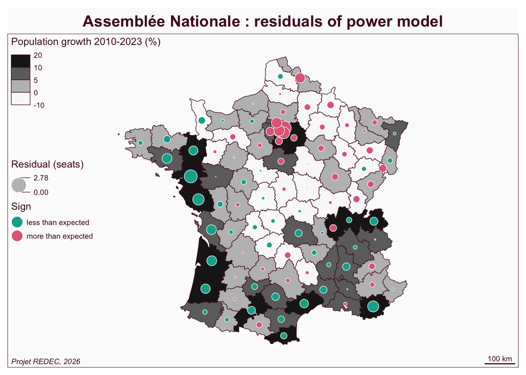

- **Comment :** The distribution of the residuals clearly correlates with changes in the population since the last revision of the number of seats in the Assemblée Nationale in 2010. The coastal regions in the West and South are clearly disadvantaged compared with the North-East. The case of the Paris suburbs is different. The fact that there are more seats than expected is probably related to choosing the number of registered voters as the explanatory variable. These residuals would probably disappear if we had chosen the total population as the explanatory variable.

### Senat

```
    Pearson's product-moment correlation

data:  log(don$I2024) and log(don$NBSEN)
t = 24.13, df = 92, p-value < 2.2e-16
alternative hypothesis: true correlation is not equal to 0
95 percent confidence interval:
 0.8952153 0.9525410
sample estimates:
      cor
0.9292749
```

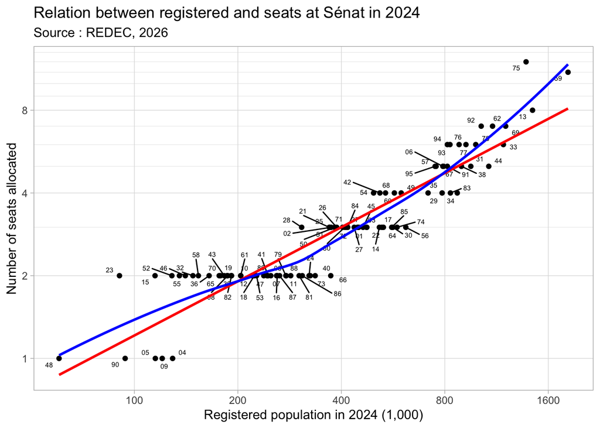

- **Comment** : The assumption of a power relationship between the number of seats in the Sénat and the number of registered citizens in 2024 remains significant. Still, it is lower than for the Assemblée Nationale ($r=0.930$ and $p < 0.001$). However, the plot reveals a strong autocorrelation problem in the residuals. The power model estimate (red) differs clearly from the non-linear LOESS estimate (blue). We can see strong heteroscedasticity due to large variations in registered populations across départements represented by 2 or 3 seats in the Sénat. For example, the département of Creuse (23) has two seats in the Sénat for only 90,000 registered citizens in 2024. Pyrénées-Orientales (66) also has two seats with 373,000 registered citizens in 2024. And Eure-et-Loir (28), with 304,000 registered citizens, has 3 seats …

| **Characteristic** | **log(IRR)** | **95% CI** | **p-value** |
| --- | --- | --- | --- |
| (Intercept) | -8.3 | -10, -6.1 | <0.001 |
| log(I2024) | 0.73 | 0.56, 0.89 | <0.001 |

Abbreviations: CI = Confidence Interval, IRR = Incidence Rate Ratio

- **Comment :** According to the model results, the allocation seems to offer a strong advantage to smaller départements ($\alpha = 0.73$). The confidence interval confirms that the parameter differs significantly from 1 ($0.56 < \alpha < 0.89$). Unlike the Assemblée Nationale, the distribution of seats in the Sénat is clearly not proportional to registration.

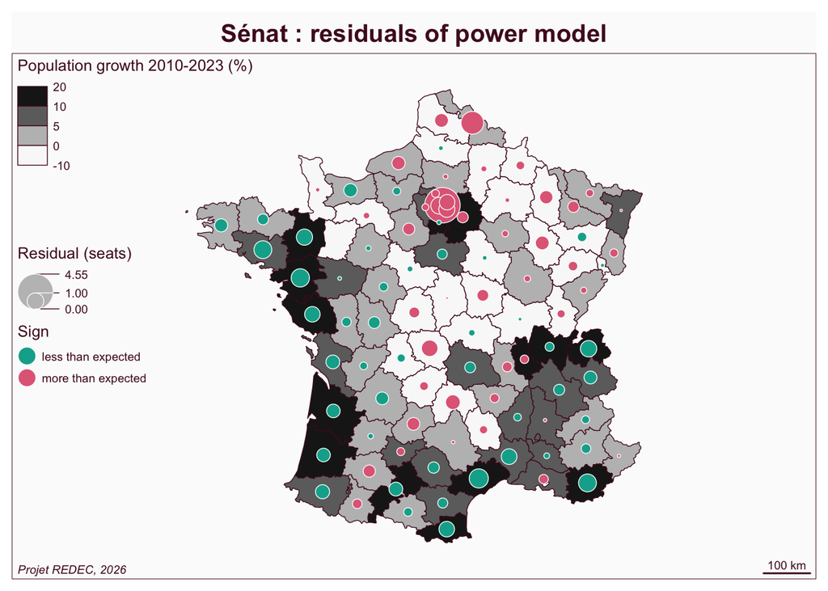

- **Comment :** The distribution of residuals for the Sénat is to some extent similar to the distribution observed for the Assemblée Nationale. We do recognise residuals in areas with large populations in the South. What differs is that the positive residuals benefit the North-East of France less than Île-de-France, and in particular the département of Paris. According to the power model, Paris should have 7.5 seats instead of 12, which means an exceptional positive residual of 4.5. But we have to keep in mind that the distribution of residuals in the case of the Senate is strongly biased by autocorrelation and heteroscedasticity.

## (C) Benchmarking Sénat and Assemblée Nationale

Without considering population or the number of registered voters, what are the differences between the Sénat and the Assemblée Nationale in terms of political representation? In other words, can we say that the Sénat better represents some départements than the Assemblée Nationale, and vice versa? To answer this question, we can estimate the number of seats in the Sénat based on the number of seats in the Assemblée Nationale, using the same model of power relations as in the previous section.

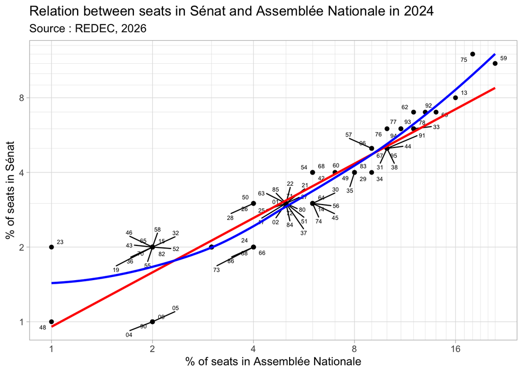

- **Comment :** This correlation diagram underlines the problem introduced by transforming population into a discrete number of seats. As we can see, many départements are characterised by similar allocations of seats, with typical situations like 2 seats in both assemblies (12 cases) or 5 seats in the Assemblée Nationale and 3 in the Sénat (16 cases).

| **Characteristic** | **log(IRR)** | **95% CI** | **p-value** |
| --- | --- | --- | --- |
| (Intercept) | -0.14 | -0.49, 0.19 | 0.4 |
| log(NBDEP) | 0.79 | 0.62, 0.97 | <0.001 |

Abbreviations: CI = Confidence Interval, IRR = Incidence Rate Ratio

- **Comment** : According to the results of the model, the relation is significant ($r=0.932$ and $p <0.001$), but the coefficient of the power relation is clearly lower than 1 ($\alpha = 0.79$) with a confidence interval ($0.62 < \alpha < 0.97$). We can therefore establish the following rule :

$NB.SENAT_i = 0.87 \times (NB.DEPUT_i)^{0.79}$

This result means that the département with the smallest population (characterised by low population density) will be better represented in the Sénat than in the Assemblée Nationale. This is visible if we convert the number of seats to percentages and compute the difference.

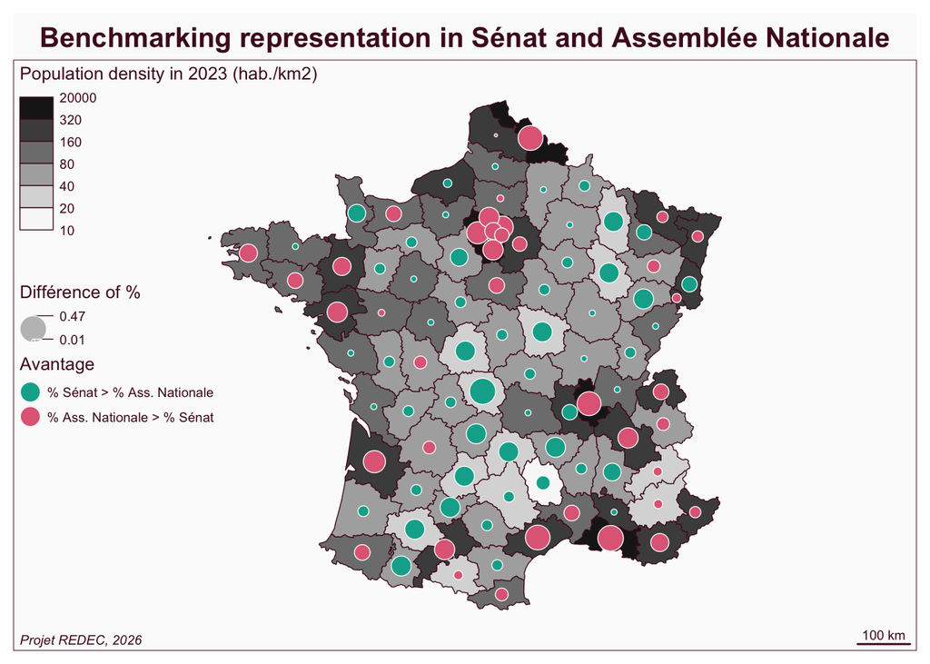

- **Comment** : The map reveals a clear relationship between the population density of départements and their representation in the Sénat (low density) and the Assemblée Nationale (high density). The départements with better representation in the Sénat belong to what is generally called the “diagonale du vide”, from the Ardennes to the Pyrénées. The départements with better representation in the Assemblée Nationale are typically those where the most important cities and metropolitan areas are located (Paris, Lille, Marseille, Nantes, Bordeaux, Toulouse, Montpellier, Grenoble, …).

The fact that the Senate presents itself as a chamber representing *territories* rather than *citizens* is not in itself shocking. Many countries have, in fact, structured their second chamber not on a basis proportional to population but rather to the number of autonomous political entities. For example, each department could send two representatives to the Senate. One could even imagine each department having representation in the Senate proportional to its *area*, if the word ‘territory’ is taken in its geometric sense. The Gironde, with an area of 9,976 km², would then have almost 100 times as many senators as the department of Paris, with its 105 km². But one might perhaps hesitate to apply this rule to French Guiana and its 83,856 km²…

The observed link between population density and over-representation in the Senate, compared with the National Assembly, is largely an artefact. It results from an imperfect proportionality law combined with an outdated census reference framework that favours territories whose populations have grown the least. If one were genuinely to ensure objective representation for the least densely populated territories, a new measure would need to be devised, combining, for example, the share of the population and the share of the departments’ total area according to a precise rule of the following type:

$Weight_i = (\frac{Area_i}{Total_area})^\mu \times (\frac{Pop_i}{Total_pop})^{1-\mu}$

But are departments really the best level at which to make decisions?

## (D) The legal point of view

### The revision of 1966

The definition of the number of seats in Senat was modified in 1966 by the [law 66-504 from 12-07-1966](https://www.legifrance.gouv.fr/jorf/id/JORFTEXT000000504684). One of the reason of the revision was the modification of the departements of Seine and Seine-et-Oise, replaced by 7 new départements. The consequence of the revision was an increase of the number of sénateurs from 30 to 39 in this area and from 255 to 264 in the metropolitan area of France. We can notice that the increase (+9) of seats was limited to the metropolitan area of Paris, without considerng other départements where population changes could have justify changes.

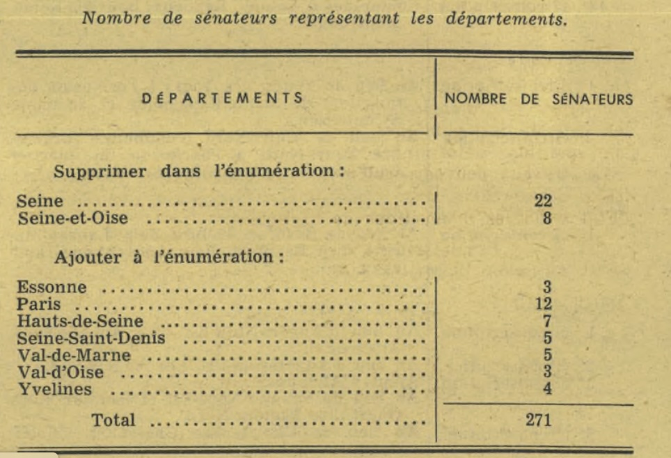

Revision of senateurs in Paris region, 1966

### The revision of 2003

The last revision of the number of seats in Sénat was decided in 2003 in order to take into account demographic changes. But the rule adopted was criticized and contested by left-wing party which asked to the Conseil Constitutionnel a censorship. This censorship was not adopted but it is interesting to look at the motivation of the decision :

**The decision 2003-475 DC from Conseil Constitutionnel**

Les dispositions combinées de l’article 6 de la Déclaration de 1789 et des articles 3 et 24 de la Constitution imposent au législateur de modifier la répartition par département des sièges de sénateurs pour tenir compte des évolutions de la population des collectivités territoriales dont le Sénat assure la représentation. Pour modifier la répartition par département des sièges de sénateurs figurant au tableau n° 6 annexé à la partie législative du code électoral, le législateur a retenu un système de répartition par tranches, soit un sénateur jusqu’à 150 000 habitants, puis un sénateur supplémentaire par tranche ou fraction de tranche de 250 000 habitants. Si l’application d’un tel système maintient certaines disparités démographiques, les modifications qui résultent de la loi déférée n’en réduisent pas moins sensiblement les inégalités de représentation antérieures. En conservant aux départements de la Creuse et de Paris leur représentation antérieure, le législateur a apporté une dérogation au mode de calcul qu’il avait lui-même retenu. Toutefois, pour regrettable qu’elle soit, cette dérogation, qui intéresse 4 sièges, ne porte pas au principe d’égalité devant le suffrage une atteinte telle qu’elle entacherait d’inconstitutionnalité la loi déférée. Eu égard au rôle confié au Sénat par l’article 24 de la Constitution, la nouvelle répartition des sièges n’est pas contraire à la Constitution.

(2003-475 DC, 24 juillet 2003, cons. 2, 3, 5, 6, 7, 8, Journal officiel du 31 juillet 2003, page 13038)

### The rule of 2003 (version 1)

The interest of the judgement of 2003 is to provide an explicit formulation of the rule used for the definition of the number of seats which was formulated as follow :

- **rule 1** : One seat for each département until 150 000 h
- **rule 2** : One seat more for each “*tranche*” or “*number of tranche*” of 250 000 h

Which can be formalized, if we undestrand correctly by the formula :

$Y = 1 + round(\frac{X-150000}{250000})$

If we assume that the law was based on the census of 1999 which was the last available at that time, can we verify that the application was correct with the exceptions of Creuse and Paris ?

| dept | dept_nom | P1999 | NBSEN | MIN | SUP | TOT | DIF |
| --- | --- | --- | --- | --- | --- | --- | --- |
| 75 | Paris | 2125246 | 12 | 1 | 7.900984 | 9 | 3 |
| 01 | Ain | 515270 | 3 | 1 | 1.461080 | 2 | 1 |
| 06 | Alpes-Maritimes | 1011326 | 5 | 1 | 3.445304 | 4 | 1 |
| 12 | Aveyron | 263808 | 2 | 1 | 0.455232 | 1 | 1 |
| 15 | Cantal | 150778 | 2 | 1 | 0.003112 | 1 | 1 |
| 19 | Corrèze | 232576 | 2 | 1 | 0.330304 | 1 | 1 |
| 21 | Côte-d’Or | 506755 | 3 | 1 | 1.427020 | 2 | 1 |
| 23 | Creuse | 124470 | 2 | 1 | -0.102120 | 1 | 1 |
| 25 | Doubs | 499062 | 3 | 1 | 1.396248 | 2 | 1 |
| 26 | Drôme | 437778 | 3 | 1 | 1.151112 | 2 | 1 |
| 28 | Eure-et-Loir | 407665 | 3 | 1 | 1.030660 | 2 | 1 |
| 32 | Gers | 172335 | 2 | 1 | 0.089340 | 1 | 1 |
| 36 | Indre | 231139 | 2 | 1 | 0.324556 | 1 | 1 |
| 39 | Jura | 250857 | 2 | 1 | 0.403428 | 1 | 1 |
| 42 | Loire | 728524 | 4 | 1 | 2.314096 | 3 | 1 |
| 43 | Haute-Loire | 209113 | 2 | 1 | 0.236452 | 1 | 1 |
| 46 | Lot | 160197 | 2 | 1 | 0.040788 | 1 | 1 |
| 49 | Maine-et-Loire | 732657 | 4 | 1 | 2.330628 | 3 | 1 |
| 50 | Manche | 481983 | 3 | 1 | 1.327932 | 2 | 1 |
| 52 | Haute-Marne | 194873 | 2 | 1 | 0.179492 | 1 | 1 |
| 54 | Meurthe-et-Moselle | 713779 | 4 | 1 | 2.255116 | 3 | 1 |
| 55 | Meuse | 192198 | 2 | 1 | 0.168792 | 1 | 1 |
| 57 | Moselle | 1023447 | 5 | 1 | 3.493788 | 4 | 1 |
| 58 | Nièvre | 225198 | 2 | 1 | 0.300792 | 1 | 1 |
| 60 | Oise | 766441 | 4 | 1 | 2.465764 | 3 | 1 |
| 62 | Pas-de-Calais | 1441568 | 7 | 1 | 5.166272 | 6 | 1 |
| 65 | Hautes-Pyrénées | 222368 | 2 | 1 | 0.289472 | 1 | 1 |
| 68 | Haut-Rhin | 708025 | 4 | 1 | 2.232100 | 3 | 1 |
| 70 | Haute-Saône | 229732 | 2 | 1 | 0.318928 | 1 | 1 |
| 76 | Seine-Maritime | 1239138 | 6 | 1 | 4.356552 | 5 | 1 |
| 77 | Seine-et-Marne | 1193767 | 6 | 1 | 4.175068 | 5 | 1 |
| 82 | Tarn-et-Garonne | 206034 | 2 | 1 | 0.224136 | 1 | 1 |
| 84 | Vaucluse | 499685 | 3 | 1 | 1.398740 | 2 | 1 |
| 92 | Hauts-de-Seine | 1428881 | 7 | 1 | 5.115524 | 6 | 1 |
| 94 | Val-de-Marne | 1227250 | 6 | 1 | 4.309000 | 5 | 1 |

We observe clearly that our version 1 of the rule is not correct because they are 35 départements with positive residuals.

### The rule of 2003 (version 2)

The correct version of the rule of 2003 seems to be different and should be better interpreted as the addition of a new seat whatever the decimal.

$Y = 1+round(\frac{X-150000}{250000} +0.5)$

| dept | dept_nom | P1999 | NBSEN | MIN | SUP | TOT | DIF |
| --- | --- | --- | --- | --- | --- | --- | --- |
| 75 | Paris | 2125246 | 12 | 1 | 7.900984 | 9 | 3 |
| 23 | Creuse | 124470 | 2 | 1 | -0.102120 | 1 | 1 |

We obtain the correct result with the two exceptions of Creuse and Paris described by the conseil constitutionnel.

### Transposition to 2023

We can now apply the rule of 2003 to the situation of 2023. Considering that the population has increased from 58.25 millions to 65.81 millions of inhabitants, we decide to modify the threshold by the coefficient of increase of the population in order to avoid an increase of seats in Senat :

$Y = 1+round(\frac{X-169445}{282408} +0.5)$

Application of the rule of 2003 to 2023

| dept | dept_nom | P2023 | NBSEN | MIN | SUP | TOT | DIF |
| --- | --- | --- | --- | --- | --- | --- | --- |
| 75 | Paris | 2103778 | 12 | 1 | 6.8494271 | 8 | 4 |
| 15 | Cantal | 144196 | 2 | 1 | -0.0894061 | 1 | 1 |
| 23 | Creuse | 115527 | 2 | 1 | -0.1909224 | 1 | 1 |
| 28 | Eure-et-Loir | 433129 | 3 | 1 | 0.9336988 | 2 | 1 |
| 52 | Haute-Marne | 168331 | 2 | 1 | -0.0039446 | 1 | 1 |
| 54 | Meurthe-et-Moselle | 732236 | 4 | 1 | 1.9928295 | 3 | 1 |
| 59 | Nord | 2615635 | 11 | 1 | 8.6619005 | 10 | 1 |
| 62 | Pas-de-Calais | 1457905 | 7 | 1 | 4.5624062 | 6 | 1 |
| 76 | Seine-Maritime | 1260964 | 6 | 1 | 3.8650428 | 5 | 1 |
| 30 | Gard | 770940 | 3 | 1 | 2.1298795 | 4 | -1 |
| 31 | Haute-Garonne | 1471468 | 5 | 1 | 4.6104324 | 6 | -1 |
| 33 | Gironde | 1690493 | 6 | 1 | 5.3859947 | 7 | -1 |
| 34 | Hérault | 1230289 | 4 | 1 | 3.7564233 | 5 | -1 |
| 35 | Ille-et-Vilaine | 1120666 | 4 | 1 | 3.3682509 | 5 | -1 |
| 44 | Loire-Atlantique | 1487570 | 5 | 1 | 4.6674492 | 6 | -1 |
| 56 | Morbihan | 783390 | 3 | 1 | 2.1739646 | 4 | -1 |
| 66 | Pyrénées-Orientales | 496855 | 2 | 1 | 1.1593510 | 3 | -1 |
| 69 | Rhône | 1914667 | 7 | 1 | 6.1797895 | 8 | -1 |
| 74 | Haute-Savoie | 861158 | 3 | 1 | 2.4493393 | 4 | -1 |
| 83 | Var | 1119307 | 4 | 1 | 3.3634387 | 5 | -1 |
| 91 | Essonne | 1338485 | 5 | 1 | 4.1395428 | 6 | -1 |
| 93 | Seine-Saint-Denis | 1704316 | 6 | 1 | 5.4349416 | 7 | -1 |

```
[1] 313
```

```
   Min. 1st Qu.  Median    Mean 3rd Qu.    Max.
-13.620   2.751   9.573  10.907  18.121  40.630
```

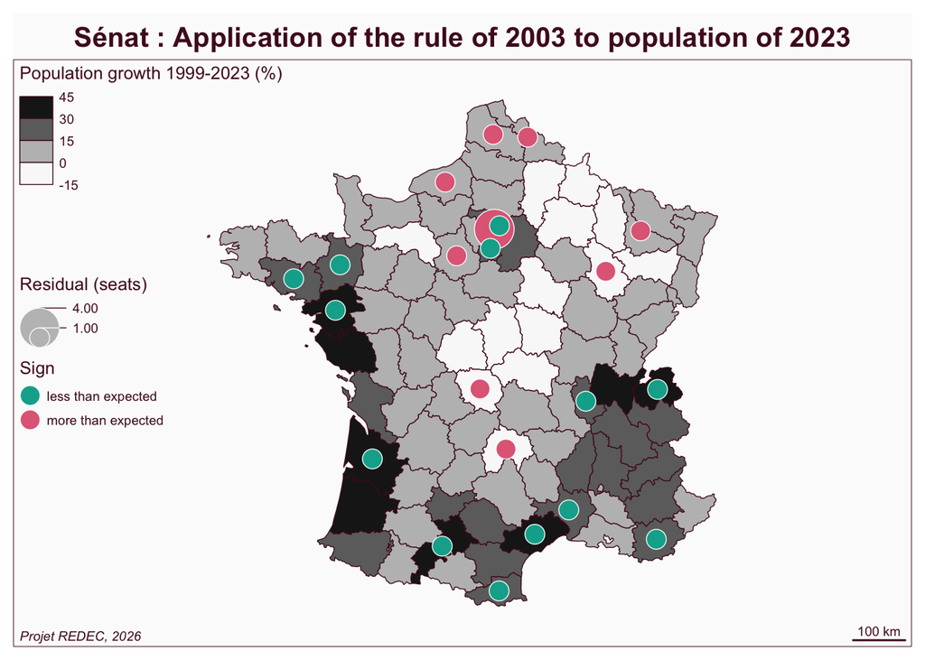

## Conclusion

The different analysis realized with the **power model** has revealed that the number of seats in Sénat is clearly not proportional to population and provide a very important advantage to départements with low population which are generally characterized by low density. The coefficient of the power law linking population and seats is clearly lower than 1 which means that the allocation of seats is strongly biased by what the geographers call the MAUP (Modifiable Area Unit Problem). The merging of two departements in one would necessary decrease their number of seats when the splitting would increase the number of seats. It is unfair and certainly not logical.

The legal analysis of the rule of 2003 suggest that the problem is strongly enhanced in the formula used for the allocation of seats. The application of the same rule to the demographic data of 2023 would not change the inequalities revealed by the power model. It is clearly the rule that should be modified.